# Биостатистика. Экзамен

95-871

2025-06-09

# Задание 1 + Задание 2

Проведите разведывательный анализ данных, оценив входящие в датасет переменные. Выберите из них одну количественную и одну качественную переменные. При этом качественная переменная должна содержать не менее трех уровней.

Оцените характер распределения количественной переменной и рассчитайте ключевые параметры описательной статистики, наиболее корректно представляющие эти данные (с учетом типа распределения). Разделите переменную, содержащую возраст пациента в годах, на возрастные группы по 25 лет (0–24, 25–49 и т. д.). Для качественной переменной рассчитайте параметры описательной статистики с учетом разделения на возрастные группы.

Постройте необходимые графики для визуализации проверки характера распределения, а также ключевых параметров описательной статистики, для наиболее полного представления данных по выбранным переменным. Интерпретируйте полученные результаты.

```r
library(dplyr)
```

```r
library(skimr)
library(corrplot)
library(ggplot2)
library(patchwork)
library(rstatix)
library(car)
library(FSA)
library(broom)
library(stats)
library(lmtest)
library(ResourceSelection)
```

```
## ResourceSelection 0.3-6   2023-06-27
```

```r
library(pROC)
# загрузка датасета
kdd_raw <- read.csv("kidney_disease_dataset.csv")
glimpse(kdd_raw)
```

```
## Rows: 20,538
## Columns: 43
## $ Age.of.the.patient                          <int> 54, 42, 38, 7, 67, 14, 9, …
## $ Blood.pressure..mm.Hg.                      <int> 167, 127, 148, 98, 174, 92…
## $ Specific.gravity.of.urine                   <dbl> 1.023, 1.023, 1.016, 1.017…
## $ Albumin.in.urine                            <int> 1, 3, 0, 4, 1, 4, 2, 5, 4,…
## $ Sugar.in.urine                              <int> 4, 2, 0, 0, 1, 2, 0, 3, 4,…
## $ Red.blood.cells.in.urine                    <chr> "normal", "normal", "abnor…
## $ Pus.cells.in.urine                          <chr> "abnormal", "normal", "nor…
## $ Pus.cell.clumps.in.urine                    <chr> "not present", "not presen…
## $ Bacteria.in.urine                           <chr> "not present", "present", …
## $ Random.blood.glucose.level..mg.dl.          <int> 96, 73, 77, 225, 376, 371,…
## $ Blood.urea..mg.dl.                          <dbl> 169.10137, 183.22348, 193.…
## $ Serum.creatinine..mg.dl.                    <dbl> 7.55, 13.37, 9.49, 10.98, …
## $ Sodium.level..mEq.L.                        <dbl> 146.0684, 123.5014, 149.45…
```

[output cut: 30 more lines]

```r
# преобразуем строковые переменные в факторы
kdd <- kdd_raw %>%
  mutate_if(is.character, as.factor)

# упорядочим факторы
target_levels <- c("No_Disease", "Low_Risk", "Moderate_Risk", "High_Risk", "Severe_Disease")
pa_levels <- c("low", "moderate", "high")
kdd <- kdd %>%
  mutate(Target = factor(Target, levels = target_levels),
         Physical.activity.level = factor(Physical.activity.level, levels = pa_levels))

# разведочный анализ данных

# обзор
skim(kdd)
```

Data summary

| Name | kdd |
| --- | --- |
| Number of rows | 20538 |
| Number of columns | 43 |
| _______________________ |  |
| Column type frequency: |  |
| factor | 15 |
| numeric | 28 |
| ________________________ |  |
| Group variables | None |

**Variable type: factor**

| skim_variable | n_missing | complete_rate | ordered | n_unique | top_counts |
| --- | --- | --- | --- | --- | --- |
| Red.blood.cells.in.urine | 0 | 1 | FALSE | 2 | nor: 10272, abn: 10266 |
| Pus.cells.in.urine | 0 | 1 | FALSE | 2 | abn: 10274, nor: 10264 |
| Pus.cell.clumps.in.urine | 0 | 1 | FALSE | 2 | pre: 10298, not: 10240 |
| Bacteria.in.urine | 0 | 1 | FALSE | 2 | not: 10353, pre: 10185 |
| Hypertension..yes.no. | 0 | 1 | FALSE | 2 | yes: 10311, no: 10227 |
| Diabetes.mellitus..yes.no. | 0 | 1 | FALSE | 2 | no: 10300, yes: 10238 |
| Coronary.artery.disease..yes.no. | 0 | 1 | FALSE | 2 | yes: 10303, no: 10235 |
| Appetite..good.poor. | 0 | 1 | FALSE | 2 | goo: 10384, poo: 10154 |
| Pedal.edema..yes.no. | 0 | 1 | FALSE | 2 | yes: 10287, no: 10251 |
| Anemia..yes.no. | 0 | 1 | FALSE | 2 | yes: 10402, no: 10136 |
| Family.history.of.chronic.kidney.disease | 0 | 1 | FALSE | 2 | no: 10323, yes: 10215 |
| Smoking.status | 0 | 1 | FALSE | 2 | no: 10293, yes: 10245 |
| Physical.activity.level | 0 | 1 | FALSE | 3 | low: 6869, hig: 6869, mod: 6800 |
| Urinary.sediment.microscopy.results | 0 | 1 | FALSE | 2 | abn: 10302, nor: 10236 |
| Target | 0 | 1 | FALSE | 5 | No_: 16432, Low: 2054, Mod: 821, Hig: 821 |

**Variable type: numeric**

| skim_variable | n_missing | complete_rate | mean | sd | p0 | p25 | p50 | p75 | p100 | hist |
| --- | --- | --- | --- | --- | --- | --- | --- | --- | --- | --- |
| Age.of.the.patient | 0 | 1 | 47.48 | 24.94 | 5.0 | 26.00 | 47.00 | 69.00 | 90.00 | ▇▇▇▇▇ |
| Blood.pressure..mm.Hg. | 0 | 1 | 130.35 | 29.06 | 80.0 | 105.00 | 131.00 | 156.00 | 180.00 | ▇▇▇▇▇ |
| Specific.gravity.of.urine | 0 | 1 | 1.02 | 0.01 | 1.0 | 1.01 | 1.01 | 1.02 | 1.02 | ▇▇▇▇▆ |
| Albumin.in.urine | 0 | 1 | 2.50 | 1.70 | 0.0 | 1.00 | 3.00 | 4.00 | 5.00 | ▇▅▅▃▃ |
| Sugar.in.urine | 0 | 1 | 2.49 | 1.70 | 0.0 | 1.00 | 2.00 | 4.00 | 5.00 | ▇▅▅▅▃ |
| Random.blood.glucose.level..mg.dl. | 0 | 1 | 284.63 | 124.63 | 70.0 | 176.00 | 284.50 | 393.00 | 500.00 | ▇▇▇▇▇ |
| Blood.urea..mg.dl. | 0 | 1 | 104.09 | 55.73 | 7.0 | 55.86 | 104.40 | 152.48 | 199.99 | ▇▇▇▇▇ |
| Serum.creatinine..mg.dl. | 0 | 1 | 7.78 | 4.18 | 0.5 | 4.20 | 7.78 | 11.43 | 15.00 | ▇▇▇▇▇ |
| Sodium.level..mEq.L. | 0 | 1 | 135.08 | 8.65 | 120.0 | 127.56 | 135.04 | 142.61 | 150.00 | ▇▇▇▇▇ |
| Potassium.level..mEq.L. | 0 | 1 | 4.99 | 0.87 | 3.5 | 4.23 | 4.99 | 5.75 | 6.50 | ▇▇▇▇▇ |
| Hemoglobin.level..gms. | 0 | 1 | 11.96 | 3.45 | 6.0 | 9.00 | 11.90 | 14.90 | 18.00 | ▇▇▇▇▇ |
| Packed.cell.volume…. | 0 | 1 | 37.50 | 10.41 | 20.0 | 28.00 | 38.00 | 47.00 | 55.00 | ▇▇▇▇▇ |
| White.blood.cell.count..cells.cumm. | 0 | 1 | 9033.07 | 3481.77 | 3000.0 | 6016.00 | 9084.50 | 12062.00 | 15000.00 | ▇▇▇▇▇ |
| Red.blood.cell.count..millions.cumm. | 0 | 1 | 4.24 | 1.01 | 2.5 | 3.40 | 4.20 | 5.10 | 6.00 | ▇▇▇▇▇ |
| Estimated.Glomerular.Filtration.Rate..eGFR. | 0 | 1 | 62.23 | 33.35 | 5.0 | 33.04 | 62.14 | 91.22 | 120.00 | ▇▇▇▇▇ |
| Urine.protein.to.creatinine.ratio | 0 | 1 | 2.28 | 1.27 | 0.1 | 1.18 | 2.28 | 3.37 | 4.50 | ▇▇▇▇▇ |
| Urine.output..ml.day. | 0 | 1 | 1653.68 | 776.21 | 300.0 | 983.00 | 1645.00 | 2333.00 | 3000.00 | ▇▇▇▇▇ |
| Serum.albumin.level | 0 | 1 | 3.26 | 0.72 | 2.0 | 2.63 | 3.25 | 3.88 | 4.50 | ▇▇▇▇▇ |
| Cholesterol.level | 0 | 1 | 200.24 | 57.86 | 100.0 | 150.00 | 200.00 | 250.00 | 300.00 | ▇▇▇▇▇ |
| Parathyroid.hormone..PTH..level | 0 | 1 | 40.27 | 17.31 | 10.0 | 25.40 | 40.42 | 55.27 | 70.00 | ▇▇▇▇▇ |
| Serum.calcium.level | 0 | 1 | 9.00 | 0.87 | 7.5 | 8.25 | 8.99 | 9.75 | 10.50 | ▇▇▇▇▇ |
| Serum.phosphate.level | 0 | 1 | 4.24 | 1.01 | 2.5 | 3.38 | 4.23 | 5.11 | 6.00 | ▇▇▇▇▇ |
| Body.Mass.Index..BMI. | 0 | 1 | 27.54 | 7.22 | 15.0 | 21.30 | 27.60 | 33.80 | 40.00 | ▇▇▇▇▇ |
| Duration.of.diabetes.mellitus..years. | 0 | 1 | 14.92 | 8.96 | 0.0 | 7.00 | 15.00 | 23.00 | 30.00 | ▇▇▆▇▇ |
| Duration.of.hypertension..years. | 0 | 1 | 14.95 | 8.95 | 0.0 | 7.00 | 15.00 | 23.00 | 30.00 | ▇▇▇▇▇ |
| Cystatin.C.level | 0 | 1 | 1.75 | 0.72 | 0.5 | 1.13 | 1.75 | 2.37 | 3.00 | ▇▇▇▇▇ |
| C.reactive.protein..CRP..level | 0 | 1 | 5.06 | 2.85 | 0.1 | 2.60 | 5.07 | 7.54 | 10.00 | ▇▇▇▇▇ |
| Interleukin.6..IL.6..level | 0 | 1 | 7.70 | 4.19 | 0.5 | 4.05 | 7.71 | 11.30 | 15.00 | ▇▇▇▇▇ |

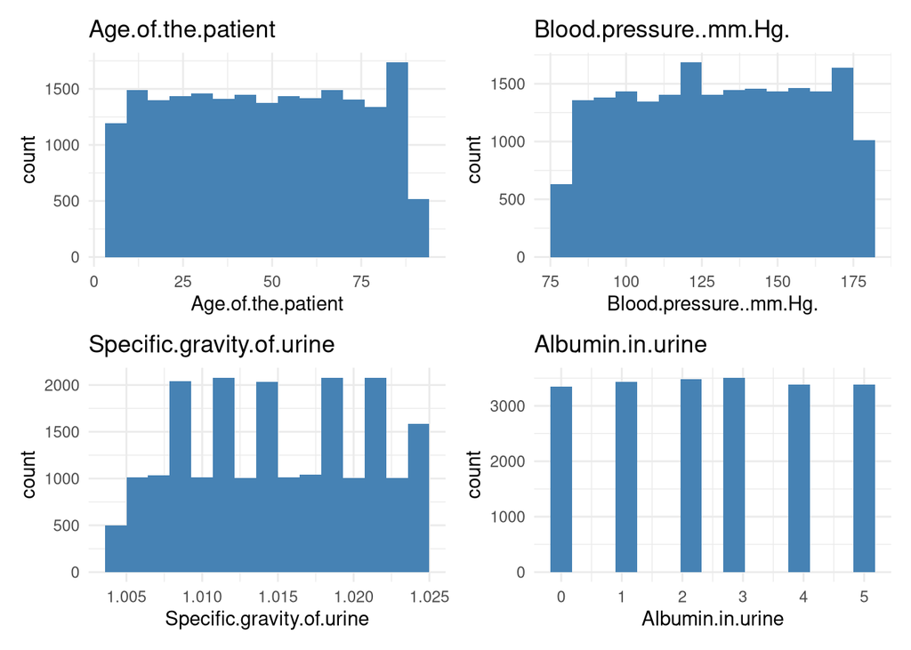

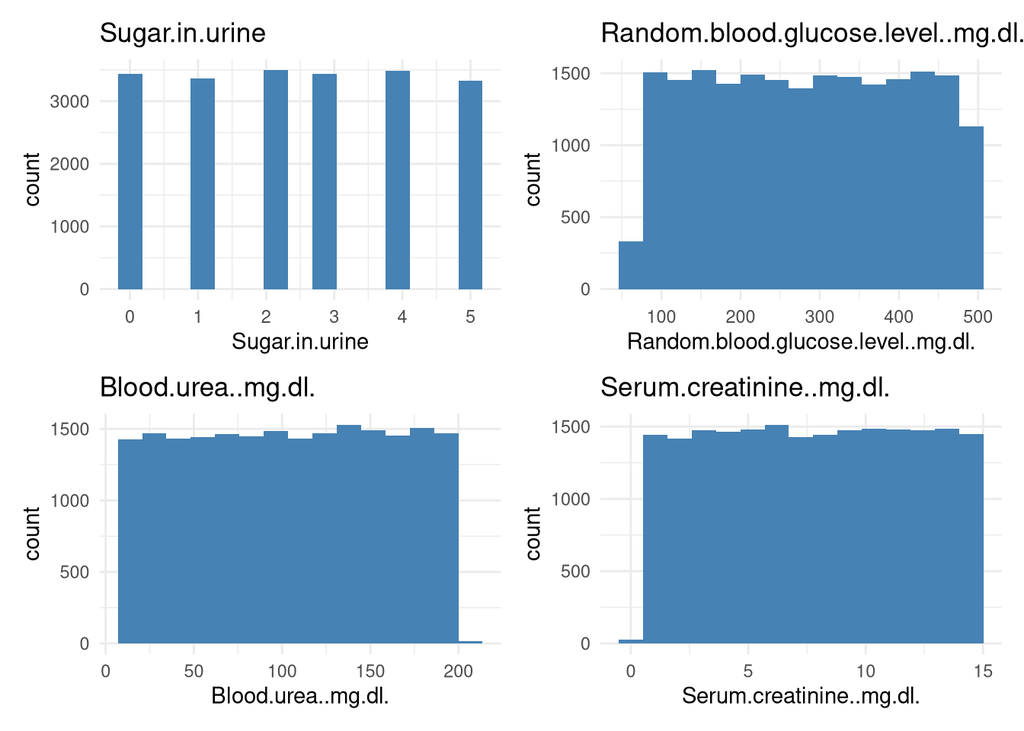

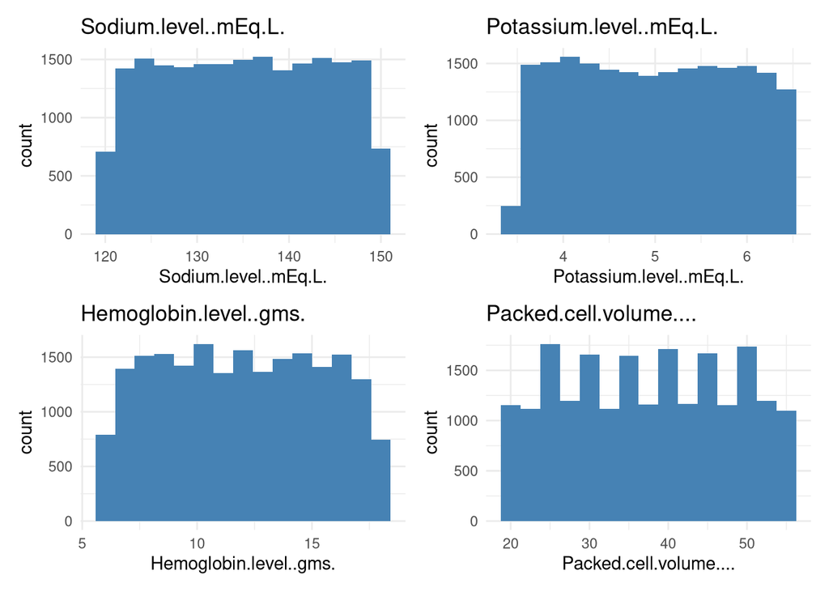

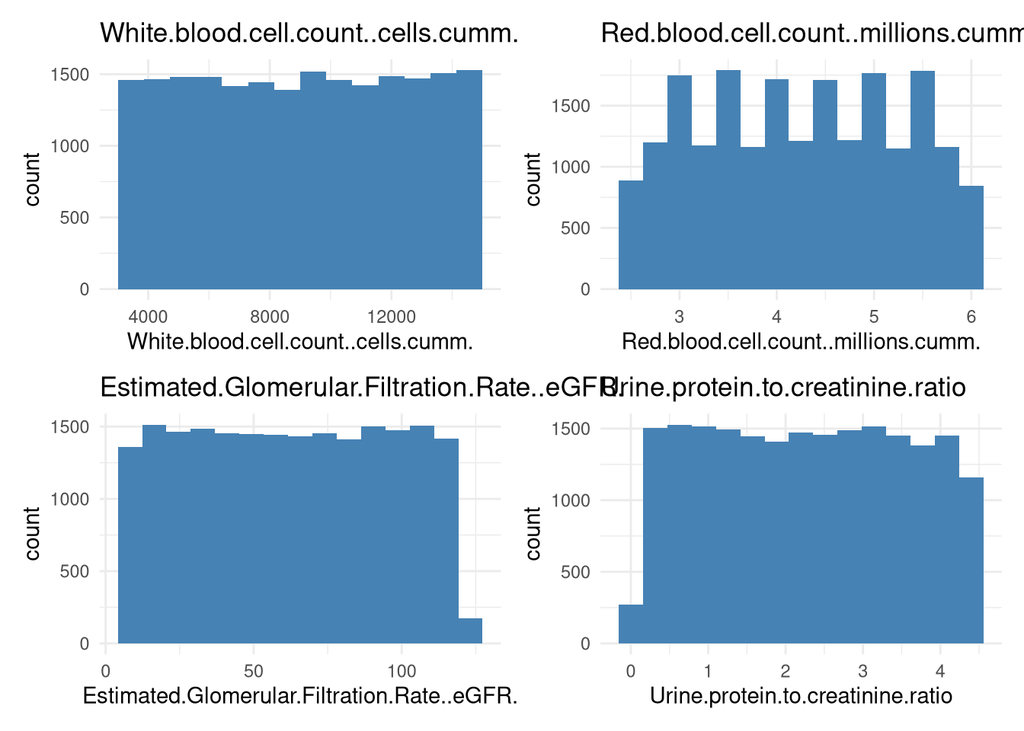

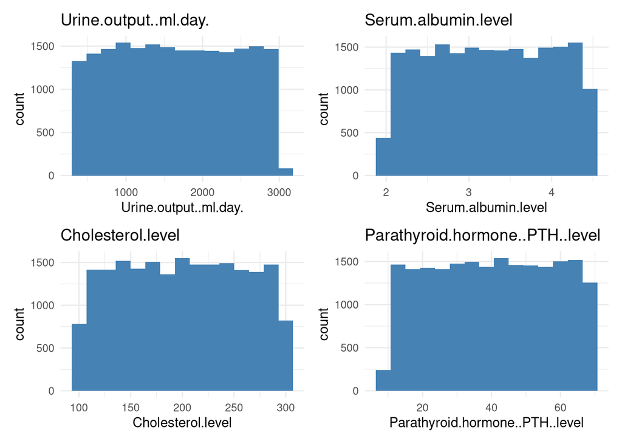

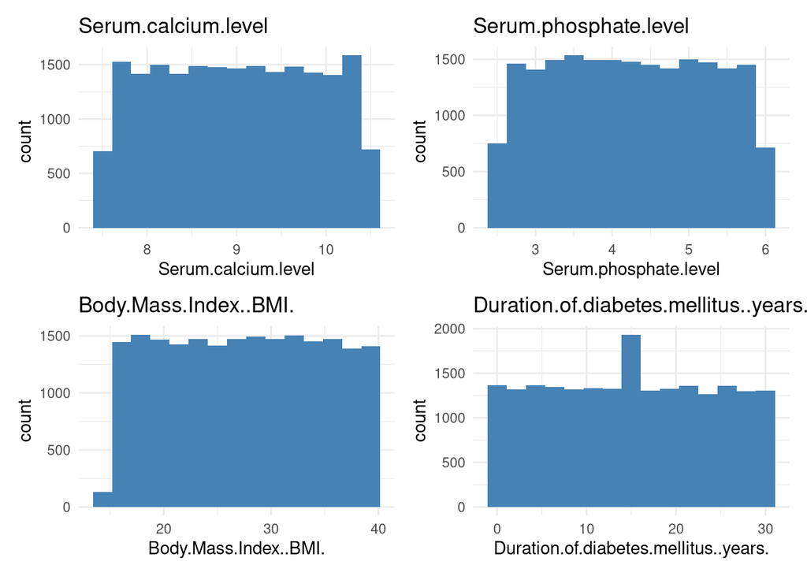

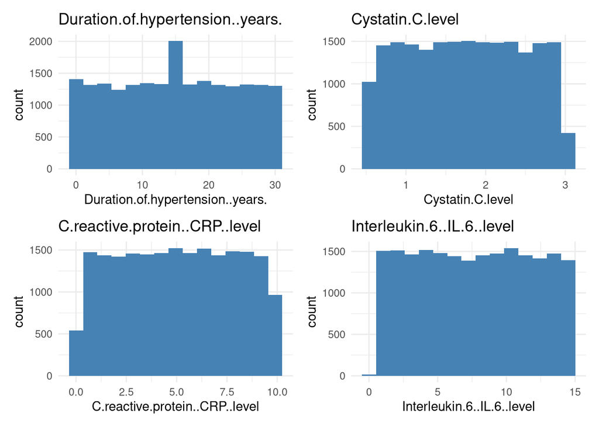

```r
# числовые переменные
num_vars <- kdd %>% select(where(is.numeric)) %>% names()
num_plots <- list()
for (var in num_vars) {
  p <- ggplot(kdd, aes(x = !!sym(var))) +
    geom_histogram(bins = 15, fill = "steelblue") +
    labs(title = var) +
    theme_minimal()

  num_plots <- append(num_plots, list(p))
}

for (i in seq(1, length(num_plots), by = 4)) {
  print(
    wrap_plots(num_plots[i:min(i + 3, length(num_plots))], ncol = 2)
  )
}
```

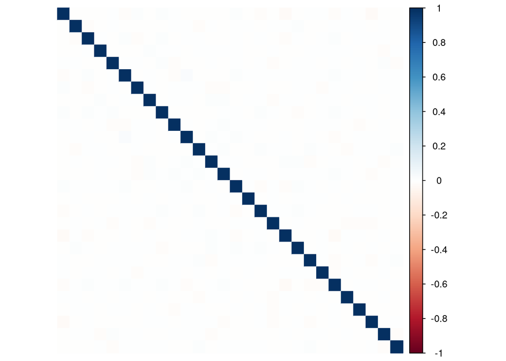

```r
# тепловая карта корреляций
correlation_matrix <- cor(kdd %>% select(where(is.numeric)))
corrplot(correlation_matrix, method = "color", tl.pos = "n")
```

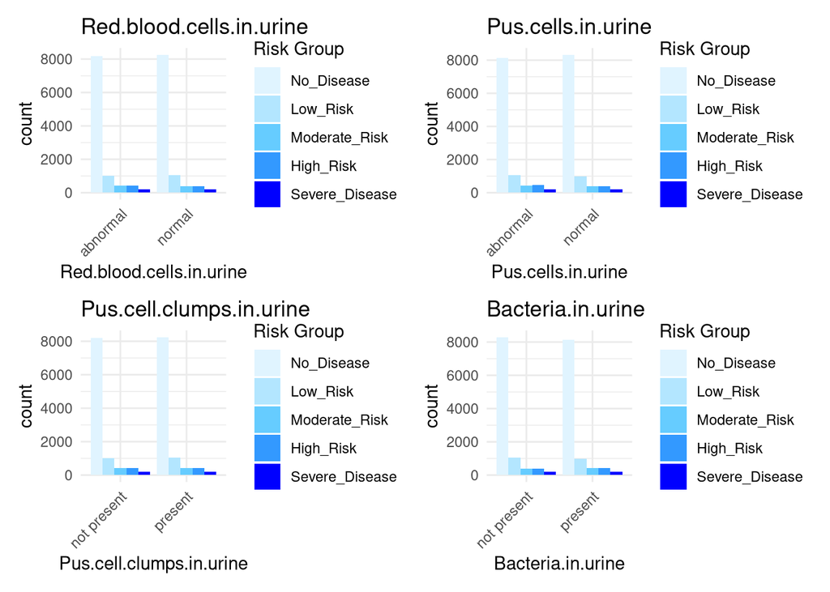

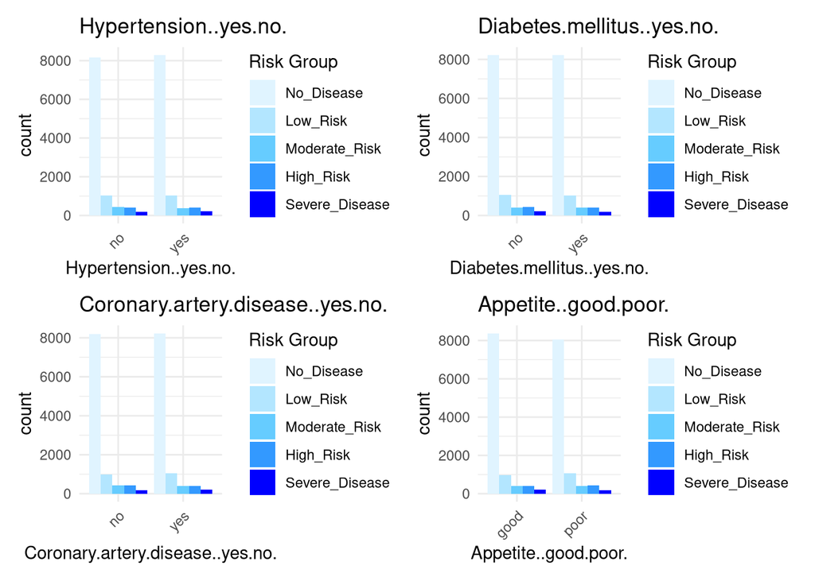

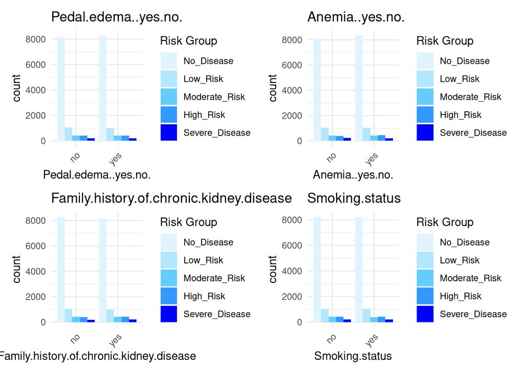

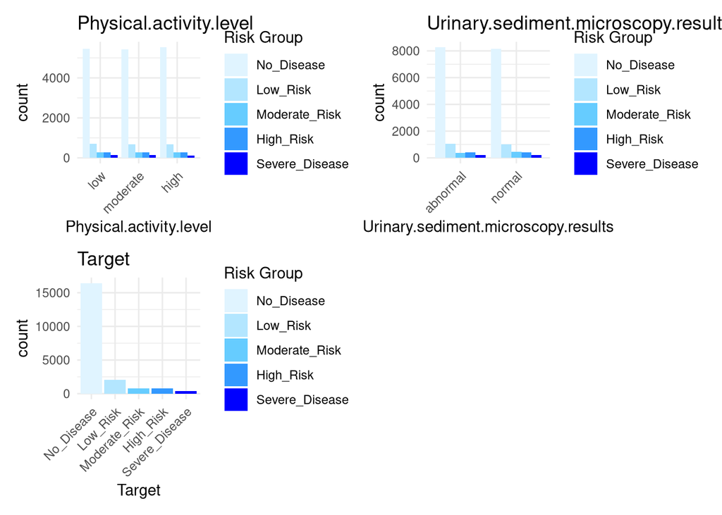

```r
# категориальные переменные
target_levels <- levels(kdd$Target)
color_palette <- c(
  "No_Disease" = "#e0f4ff",
  "Low_Risk" = "#b3e6ff",
  "Moderate_Risk" = "#66ccff",
  "High_Risk" = "#3399ff",
  "Severe_Disease" = "#0000ff"
)

cat_vars <- kdd %>% select(where(is.factor)) %>% names()
cat_plots <- list()
for (var in cat_vars) {
  p <- ggplot(kdd, aes(x = !!sym(var), fill = Target)) +
    geom_bar(position = "dodge") +
    scale_fill_manual(
      name = "Risk Group",
      values = color_palette,
      limits = target_levels
    ) +
    labs(title = var) +
    theme_minimal() +
    theme(axis.text.x = element_text(angle = 45, hjust = 1))

  cat_plots <- append(cat_plots, list(p))
}

for (i in seq(1, length(cat_plots), by = 4)) {
  print(
    wrap_plots(cat_plots[i:min(i + 3, length(cat_plots))], ncol = 2)
  )
}
```

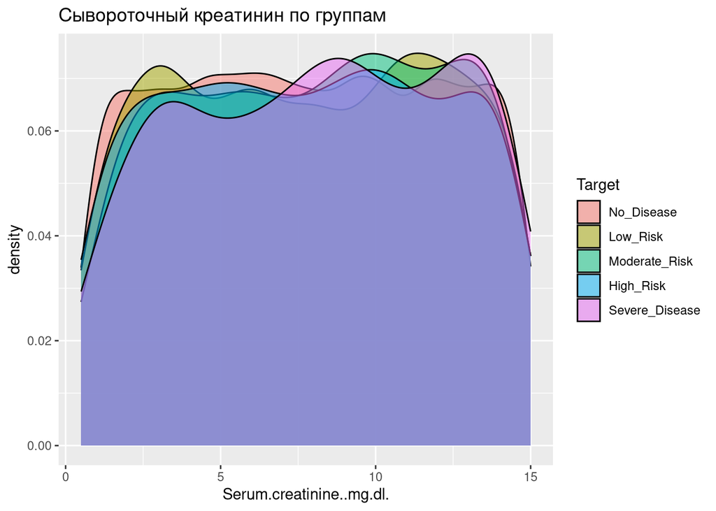

```r
# cывороточный креатинин
ggplot(kdd, aes(x = Serum.creatinine..mg.dl., fill = Target)) +
  geom_density(alpha = 0.5) +
  labs(title = "Сывороточный креатинин по группам")
```

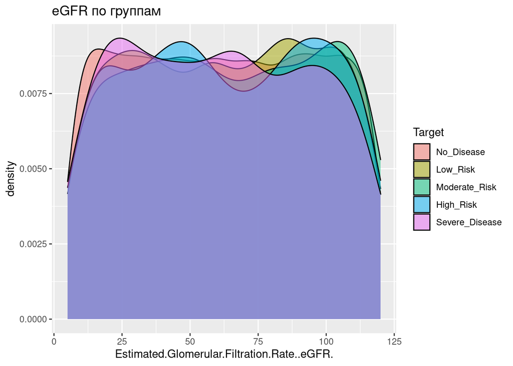

```r
# eGFR
ggplot(kdd, aes(x = Estimated.Glomerular.Filtration.Rate..eGFR., fill = Target)) +
  geom_density(alpha = 0.5) +
  labs(title = "eGFR по группам")
```

По результатам разведочного анализа можно сделать вывод, что это синтетический датасет: пропуски отсутствуют, числовые переменные имеют равномерные распределения, абсолютно не коррелируют, а ключевые показатели (например, сывороточный креатинин) имеют одинаковые распределения вне зависимости от значения целевой переменной, что не несёт смысла с медицинской точки зрения.

Дальнейшие сравнения, вероятно, не покажут значимых отличий.

Для дальнейших шагов выберем числовую переменную `Serum.creatinine..mg.dl.` и категориальную переменную `Physical.activity.level`.

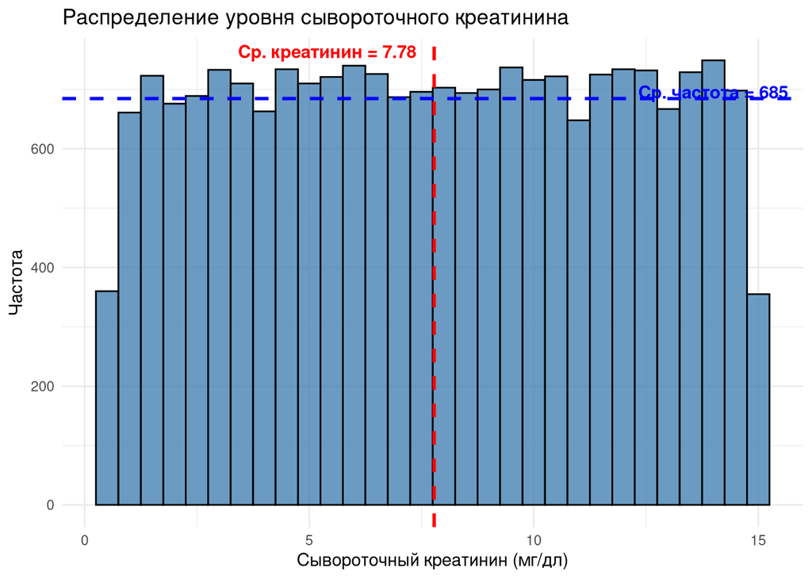

```r
# Serum.creatinine..mg.dl.

# визуализация распределения
mean_creatinine <- mean(kdd$Serum.creatinine..mg.dl., na.rm = TRUE)

hist_data <- ggplot_build(
  ggplot(kdd, aes(x = Serum.creatinine..mg.dl.)) +
    geom_histogram(bins = 30)
)$data[[1]]

mean_count <- mean(hist_data$count)

ggplot(kdd, aes(x = Serum.creatinine..mg.dl.)) +
  geom_histogram(bins = 30, fill = "steelblue", color = "black", alpha = 0.8, name = "count") +
  geom_vline(xintercept = mean_creatinine, color = "red", linetype = "dashed", size = 1) +
  geom_hline(yintercept = mean_count, color = "blue", linetype = "dashed", size = 1) +
  labs(
    title = "Распределение уровня сывороточного креатинина",
    x = "Сывороточный креатинин (мг/дл)",
    y = "Частота"
  ) +
  annotate("text", x = mean_creatinine, y = Inf,
           label = paste("Ср. креатинин =", round(mean_creatinine, 2)),
           vjust = 1.5, hjust = 1.1, color = "red", fontface = "bold") +
  annotate("text", x = Inf, y = mean_count,
           label = paste("Ср. частота =", round(mean_count, 0)),
           hjust = 1.1, vjust = 0, color = "blue", fontface = "bold") +
  theme_minimal()
```

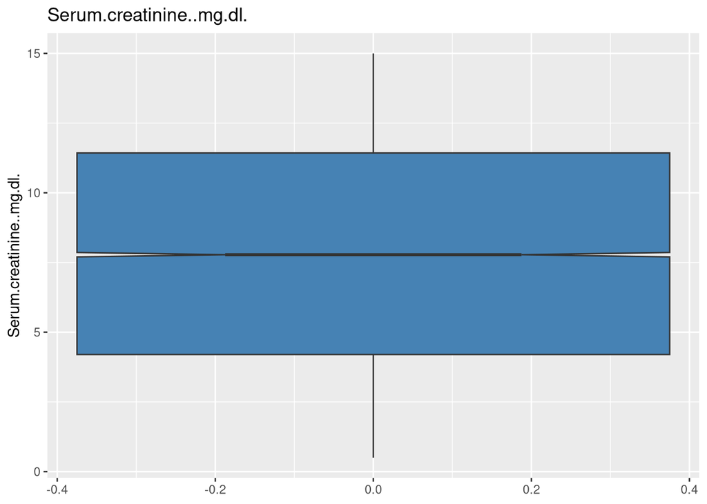

```r
ggplot(kdd, aes(y = Serum.creatinine..mg.dl.)) +
  geom_boxplot(notch = TRUE, fill = "steelblue") +
  labs(title = "Serum.creatinine..mg.dl.")
```

```r
# ключевые параметры описательной статистики
stats <- kdd %>%
  summarise(
    Min = min(Serum.creatinine..mg.dl., na.rm = TRUE),
    Q1 = quantile(Serum.creatinine..mg.dl., 0.25, na.rm = TRUE),
    Median = median(Serum.creatinine..mg.dl., na.rm = TRUE),
    Mean = mean(Serum.creatinine..mg.dl., na.rm = TRUE),
    Q3 = quantile(Serum.creatinine..mg.dl., 0.75, na.rm = TRUE),
    Max = max(Serum.creatinine..mg.dl., na.rm = TRUE),
    IQR = IQR(Serum.creatinine..mg.dl., na.rm = TRUE),
    Range = Max - Min
  )

print(stats)
```

```
##   Min  Q1 Median     Mean    Q3 Max  IQR Range
## 1 0.5 4.2   7.78 7.781865 11.43  15 7.23  14.5
```

```r
# добавляем новую категориальную переменную с возрастными группами
kdd <- kdd %>%
  mutate(
    Age_Group = case_when(
      Age.of.the.patient >= 0 & Age.of.the.patient < 25 ~ "0–24",
      Age.of.the.patient >= 25 & Age.of.the.patient < 50 ~ "25–49",
      Age.of.the.patient >= 50 & Age.of.the.patient < 75 ~ "50–74",
      Age.of.the.patient >= 75 ~ "75+"
    ),
    # преобразуем в фактор с правильным порядком
    Age_Group = factor(Age_Group, levels = c("0–24", "25–49", "50–74", "75+"))
  )

# выводим результат
table(kdd$Age_Group)
```

```
##
##  0–24 25–49 50–74   75+
##  4816  5951  5966  3805
```

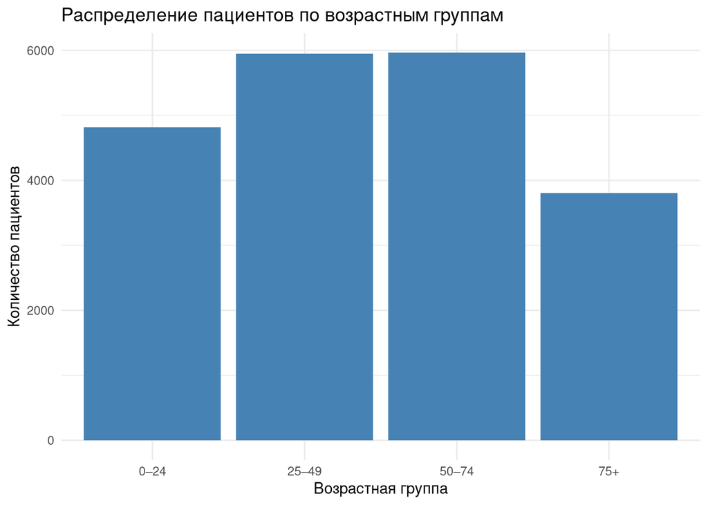

```r
# визуализация
ggplot(kdd, aes(x = Age_Group)) +
  geom_bar(fill = "steelblue") +
  labs(title = "Распределение пациентов по возрастным группам",
       x = "Возрастная группа",
       y = "Количество пациентов") +
  theme_minimal()
```

```r
# Serum.creatinine..mg.dl.: среднее и медиана по возрастным группам
kdd %>%
  group_by(Age_Group) %>%
  summarise(
    Mean_Creatinine = mean(Serum.creatinine..mg.dl., na.rm = TRUE),
    Median_Creatinine = median(Serum.creatinine..mg.dl., na.rm = TRUE)
  )
```

```
## # A tibble: 4 × 3
##   Age_Group Mean_Creatinine Median_Creatinine
##   <fct>               <dbl>             <dbl>
## 1 0–24                 7.89              7.99
## 2 25–49                7.74              7.7
## 3 50–74                7.71              7.67
## 4 75+                  7.81              7.81
```

```r
# Physical.activity.level

table(kdd$Physical.activity.level)
```

```
##
##      low moderate     high
##     6869     6800     6869
```

```r
# частоты по возрастным группам
age_activity_counts <- kdd %>%
  group_by(Age_Group, Physical.activity.level) %>%
  summarise(Count = n(), .groups = 'drop') %>%
  group_by(Age_Group) %>%
  mutate(
    Total = sum(Count),
    Relative_Freq = round(Count / Total, 3)
  )

print(age_activity_counts)
```

```
## # A tibble: 12 × 5
## # Groups:   Age_Group [4]
##    Age_Group Physical.activity.level Count Total Relative_Freq
##    <fct>     <fct>                   <int> <int>         <dbl>
##  1 0–24      low                      1590  4816         0.33
##  2 0–24      moderate                 1595  4816         0.331
##  3 0–24      high                     1631  4816         0.339
##  4 25–49     low                      2002  5951         0.336
##  5 25–49     moderate                 1959  5951         0.329
##  6 25–49     high                     1990  5951         0.334
##  7 50–74     low                      1998  5966         0.335
##  8 50–74     moderate                 1951  5966         0.327
##  9 50–74     high                     2017  5966         0.338
## 10 75+       low                      1279  3805         0.336
## 11 75+       moderate                 1295  3805         0.34
## 12 75+       high                     1231  3805         0.324
```

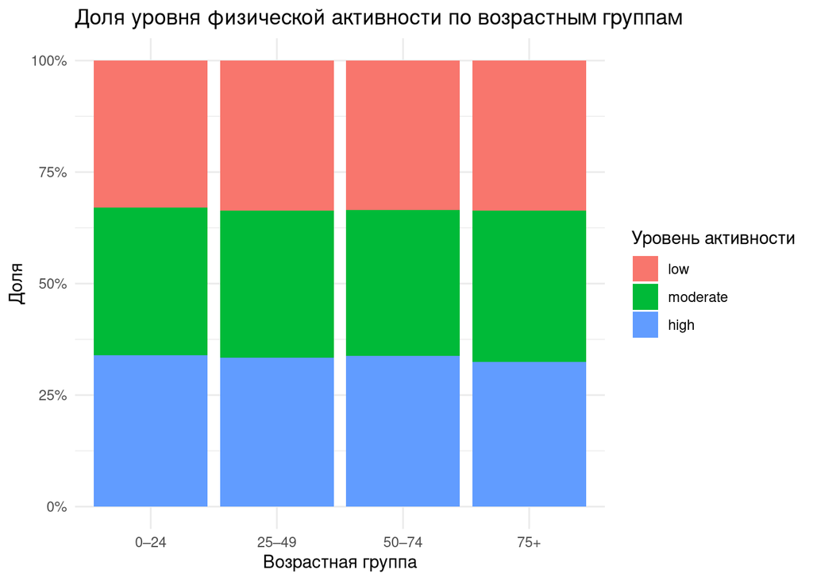

```r
# визуализация
ggplot(age_activity_counts, aes(x = Age_Group, y = Relative_Freq, fill = Physical.activity.level)) +
  geom_bar(stat = "identity", position = "fill") +
  labs(title = "Доля уровня физической активности по возрастным группам",
       x = "Возрастная группа",
       y = "Доля",
       fill = "Уровень активности") +
  scale_y_continuous(labels = scales::percent_format()) +
  theme_minimal()
```

```r
# определение моды
mode_activity <- kdd %>%
  group_by(Age_Group) %>%
  summarise(
    Mode = names(sort(table(Physical.activity.level), decreasing = TRUE))[1],
    Mode_Count = max(table(Physical.activity.level))
  )

print(mode_activity)
```

```
## # A tibble: 4 × 3
##   Age_Group Mode     Mode_Count
##   <fct>     <chr>         <int>
## 1 0–24      high           1631
## 2 25–49     low            2002
## 3 50–74     high           2017
## 4 75+       moderate       1295
```

# Задание 3

С учетом проведенных ранее процедур, выберите соответствующий статистический тест для попарного сравнения количественной переменной, разделенной на группы качественной переменной.

Выберите дополнительную качественную переменную и проведите сходную процедуру попарных сравнений. Используйте post-hoc тесты, поправки на множественные сравнения и графическую визуализацию результатов и проверки допущений тестов, где это уместно. Интерпретируйте полученные результаты.

```r
# Shapiro-Wilk: проверка нормальности распределений
set.seed(42)
kdd_sampled <- kdd %>%
  group_by(Physical.activity.level) %>%
  sample_n(size = 5000, replace = FALSE)  # 5000 - макс. размер выборки для shapiro_test
kdd_sampled %>%
  group_by(Physical.activity.level) %>%
  shapiro_test(Serum.creatinine..mg.dl.)
```

```
## # A tibble: 3 × 4
##   Physical.activity.level variable                 statistic        p
##   <fct>                   <chr>                        <dbl>    <dbl>
## 1 low                     Serum.creatinine..mg.dl.     0.956 2.35e-36
## 2 moderate                Serum.creatinine..mg.dl.     0.956 1.92e-36
## 3 high                    Serum.creatinine..mg.dl.     0.954 4.86e-37
```

```r
# Levene’s test: проверка равенства дисперсий
leveneTest(Serum.creatinine..mg.dl. ~ Physical.activity.level, data = kdd)
```

```
## Levene's Test for Homogeneity of Variance (center = median)
##          Df F value Pr(>F)
## group     2  0.1193 0.8875
##       20535
```

```r
# Kruskal-Wallis
kruskal.test(Serum.creatinine..mg.dl. ~ Physical.activity.level, data = kdd)
```

```
##
##  Kruskal-Wallis rank sum test
##
## data:  Serum.creatinine..mg.dl. by Physical.activity.level
## Kruskal-Wallis chi-squared = 3.0082, df = 2, p-value = 0.2222
```

```r
# Попарные сравнения (post-hoc) с поправкой Бонферрони
dunnTest(Serum.creatinine..mg.dl. ~ Physical.activity.level, data = kdd, method = "bonferroni")
```

```
## Dunn (1964) Kruskal-Wallis multiple comparison
```

```
##   p-values adjusted with the Bonferroni method.
```

```
##        Comparison          Z   P.unadj     P.adj
## 1      high - low  1.3339643 0.1822155 0.5466466
## 2 high - moderate -0.2954758 0.7676304 1.0000000
## 3  low - moderate -1.6260690 0.1039350 0.3118049
```

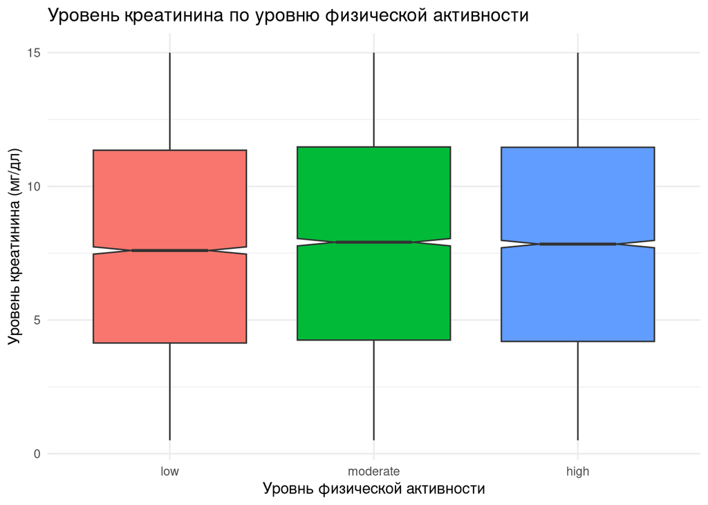

```r
# boxplot
ggplot(kdd, aes(x = Physical.activity.level, y = Serum.creatinine..mg.dl., fill = Physical.activity.level)) +
  geom_boxplot(notch = TRUE) +
  labs(
    title = "Уровень креатинина по уровню физической активности",
    x = "Уровнь физической активности",
    y = "Уровень креатинина (мг/дл)"
  ) +
  theme_minimal() +
  theme(legend.position = "none")
```

Интерпретация:

1. Проверка нормальности (Shapiro-Wilk): как и ожидалось, все три группы (low, moderate, high) имеют значительно ненормальное распределение (p < 0.001)
2. Проверка равенства дисперсий (Levene’s test): дисперсии не различаются значимо между группами.
3. Сравнение (Kruskal-Wallis test): статистически значимых различий между уровнями физической активности по уровню креатинина не выявлено.
4. Попарные сравнения (Dunn’s test с поправкой Бонферрони): все парные сравнения также не показали значимых различий.

**Вывод:**

Несмотря на то, что распределение уровня сывороточного креатинина не является нормальным и мы использовали непараметрический подход, статистически значимых различий между группами по уровню физической активности обнаружено не было.

Проведём аналогичное сравнение для групп по целевой переменной.

```r
# Shapiro-Wilk: проверка нормальности распределений
set.seed(42)
kdd_sampled_smoking <- kdd %>%
  group_by(Target) %>%
  sample_n(size = min(5000, n()), replace = FALSE)  # 5000 - макс. размер выборки для shapiro_test
kdd_sampled_smoking %>%
  group_by(Target) %>%
  shapiro_test(Serum.creatinine..mg.dl.)
```

```
## # A tibble: 5 × 4
##   Target         variable                 statistic        p
##   <fct>          <chr>                        <dbl>    <dbl>
## 1 No_Disease     Serum.creatinine..mg.dl.     0.955 8.46e-37
## 2 Low_Risk       Serum.creatinine..mg.dl.     0.952 1.75e-25
## 3 Moderate_Risk  Serum.creatinine..mg.dl.     0.955 3.00e-15
## 4 High_Risk      Serum.creatinine..mg.dl.     0.954 2.49e-15
## 5 Severe_Disease Serum.creatinine..mg.dl.     0.952 3.14e-10
```

```r
# Levene’s test: проверка равенства дисперсий
leveneTest(Serum.creatinine..mg.dl. ~ Target, data = kdd)
```

```
## Levene's Test for Homogeneity of Variance (center = median)
##          Df F value Pr(>F)
## group     4  0.5167 0.7235
##       20533
```

```r
# Kruskal-Wallis
kruskal.test(Serum.creatinine..mg.dl. ~ Target, data = kdd)
```

```
##
##  Kruskal-Wallis rank sum test
##
## data:  Serum.creatinine..mg.dl. by Target
## Kruskal-Wallis chi-squared = 6.2692, df = 4, p-value = 0.1799
```

```r
# Попарные сравнения (post-hoc)
dunnTest(Serum.creatinine..mg.dl. ~ Target, data = kdd, method = "bonferroni")
```

```
## Dunn (1964) Kruskal-Wallis multiple comparison
```

```
##   p-values adjusted with the Bonferroni method.
```

```
##                        Comparison          Z    P.unadj     P.adj
## 1            High_Risk - Low_Risk -0.2279245 0.81970495 1.0000000
## 2       High_Risk - Moderate_Risk -1.1700198 0.24199301 1.0000000
## 3        Low_Risk - Moderate_Risk -1.1706626 0.24173444 1.0000000
## 4          High_Risk - No_Disease  0.1900674 0.84925631 1.0000000
## 5           Low_Risk - No_Disease  0.6925597 0.48858591 1.0000000
## 6      Moderate_Risk - No_Disease  1.8048762 0.07109406 0.7109406
## 7      High_Risk - Severe_Disease -1.3162181 0.18810084 1.0000000
## 8       Low_Risk - Severe_Disease -1.2975324 0.19444806 1.0000000
## 9  Moderate_Risk - Severe_Disease -0.3612891 0.71788336 1.0000000
## 10    No_Disease - Severe_Disease -1.7279107 0.08400423 0.8400423
```

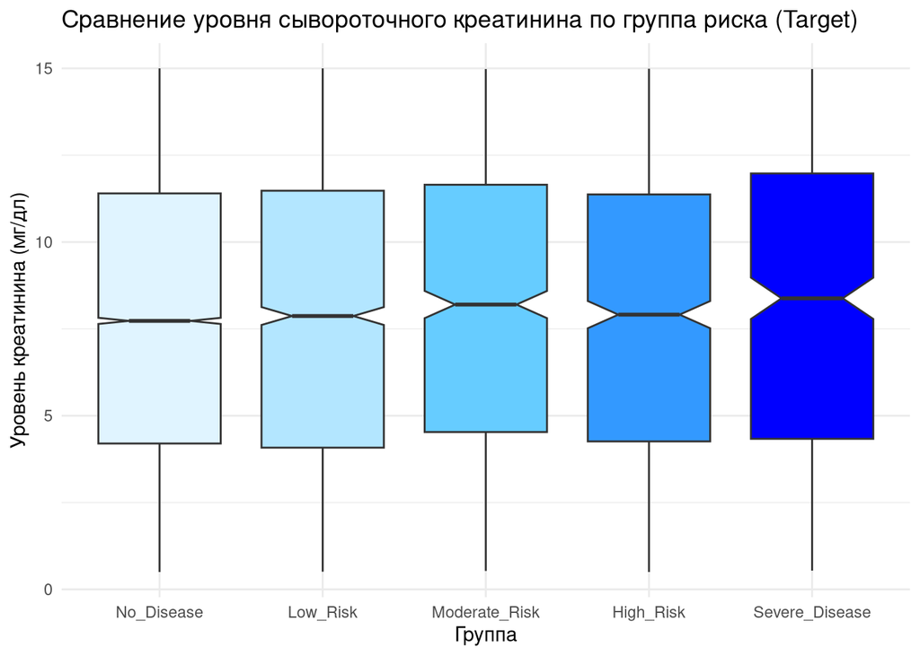

```r
# boxplot
ggplot(kdd, aes(x = Target, y = Serum.creatinine..mg.dl., fill = Target)) +
  geom_boxplot(notch = TRUE) +
   scale_fill_manual(
      name = "Risk Group",
      values = color_palette,
      limits = target_levels
    ) +
  labs(
    title = "Сравнение уровня сывороточного креатинина по группа риска (Target)",
    x = "Группа",
    y = "Уровень креатинина (мг/дл)"
  ) +
  theme_minimal() +
  theme(legend.position = "none")
```

Интерпретация:

1. Проверка нормальности (Shapiro-Wilk): все группы имеют значительно ненормальное распределение (p < 0.001)
2. Проверка равенства дисперсий (Levene’s test): дисперсии не различаются значимо между группами.
3. Сравнение (Kruskal-Wallis test): статистически значимых различий между группам по уровню креатинина не выявлено.
4. Попарные сравнения (Dunn’s test с поправкой Бонферрони): ни одно из парных сравнений также не показало значимых различий.

**Вывод:**

Статистически значимых различий между группами риска по уровню креатинина обнаружено не было.

# Задание 4

Для количественной переменной (выбранной ранее или новой) постройте модель линейной регрессии, включающую не менее трех предикторов, потенциально имеющих биологический смысл в виде причинно-следственных связей.

Проверьте необходимые допущения метода с использованием количественных тестов и графической визуализации. Интерпретируйте полученные результаты. Постройте необходимую графическую визуализацию для их презентации.

```r
# построение модели
creatinine_model <- lm(
  formula = Serum.creatinine..mg.dl. ~ Body.Mass.Index..BMI. + Age.of.the.patient + Estimated.Glomerular.Filtration.Rate..eGFR.,
  data = kdd
)

# вывод результатов
summary(creatinine_model)
```

```
##
## Call:
## lm(formula = Serum.creatinine..mg.dl. ~ Body.Mass.Index..BMI. +
##     Age.of.the.patient + Estimated.Glomerular.Filtration.Rate..eGFR.,
##     data = kdd)
##
## Residuals:
##     Min      1Q  Median      3Q     Max
## -7.3468 -3.5811  0.0011  3.6513  7.2676
##
## Coefficients:
##                                               Estimate Std. Error t value
## (Intercept)                                  7.8294835  0.1389406  56.351
## Body.Mass.Index..BMI.                        0.0018708  0.0040398   0.463
## Age.of.the.patient                          -0.0014215  0.0011697  -1.215
## Estimated.Glomerular.Filtration.Rate..eGFR. -0.0005087  0.0008746  -0.582
##                                             Pr(>|t|)
## (Intercept)                                   <2e-16 ***
## Body.Mass.Index..BMI.                          0.643
## Age.of.the.patient                             0.224
## Estimated.Glomerular.Filtration.Rate..eGFR.    0.561
## ---
## Signif. codes:  0 '***' 0.001 '**' 0.01 '*' 0.05 '.' 0.1 ' ' 1
##
## Residual standard error: 4.18 on 20534 degrees of freedom
## Multiple R-squared:  0.0001003,  Adjusted R-squared:  -4.577e-05
## F-statistic: 0.6867 on 3 and 20534 DF,  p-value: 0.56
```

```r
tidy_model <- tidy(creatinine_model)
print(tidy_model)
```

```
## # A tibble: 4 × 5
##   term                                         estimate std.error statistic
##   <chr>                                           <dbl>     <dbl>     <dbl>
## 1 (Intercept)                                  7.83      0.139       56.4
## 2 Body.Mass.Index..BMI.                        0.00187   0.00404      0.463
## 3 Age.of.the.patient                          -0.00142   0.00117     -1.22
## 4 Estimated.Glomerular.Filtration.Rate..eGFR. -0.000509  0.000875    -0.582
##   p.value
##     <dbl>
## 1   0
## 2   0.643
## 3   0.224
## 4   0.561
```

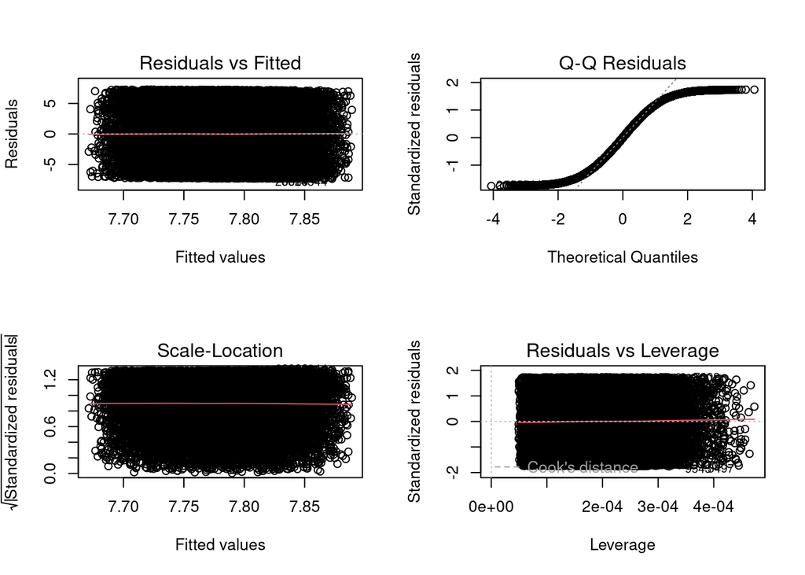

```r
# диагностические графики
par(mfrow = c(2, 2))
plot(creatinine_model)
```

```r
# оцениваем качество модели
glance(creatinine_model) %>%
  select(r.squared, adj.r.squared, sigma, AIC, BIC)
```

```
## # A tibble: 1 × 5
##   r.squared adj.r.squared sigma     AIC     BIC
##       <dbl>         <dbl> <dbl>   <dbl>   <dbl>
## 1  0.000100    -0.0000458  4.18 117042. 117082.
```

```r
# проверка мультиколлинеарности - рассчитываем VIF
vif_values <- vif(creatinine_model)

# тест на нормальность остатков (Shapiro-Wilk)
residuals_model <- residuals(creatinine_model)
# если остатков больше 5000 - делаем случайную выборку
if (length(residuals_model) > 5000) {
  set.seed(42)  # Воспроизводимость
  residuals_sample <- sample(residuals_model, 5000)
} else {
  residuals_sample <- residuals_model
}
crea_shapiro <- shapiro.test(residuals_sample)

# тест на гомоскедастичность (Breusch-Pagan Test)
crea_bp <- bptest(creatinine_model)

# автокорреляция остатков (Durbin-Watson Test)
crea_dw <- dwtest(creatinine_model)

# таблица с результатами тестов
regression_assumptions <- tibble::tibble(
  Assumption = c("Нормальность остатков", "Гомоскедастичность", "Мультиколлинеарность", "Автокорреляция"),
  Test = c("Shapiro-Wilk", "Breusch-Pagan", "VIF", "Durbin-Watson"),
  p_value = c(
    crea_shapiro$p.value,
    crea_bp$p.value,
    NA_real_,
    crea_dw$p.value
  ),
  VIF_Median = c(NA_real_, NA_real_, median(vif_values), NA_real_),
  Interpretation = case_when(
    p_value < 0.05 & Assumption == "Нормальность остатков" ~ "Остатки не нормальны",
    p_value >= 0.05 & Assumption == "Нормальность остатков" ~ "Остатки нормальны",
    p_value < 0.05 & Assumption == "Гомоскедастичность" ~ "Гетероскедастичность",
    p_value >= 0.05 & Assumption == "Гомоскедастичность" ~ "Гомоскедастичность",
    VIF_Median > 10 & Assumption == "Мультиколлинеарность" ~ "Сильная",
    VIF_Median > 5 & Assumption == "Мультиколлинеарность" ~ "Умеренная",
    TRUE ~ "Незначительная"
  )
)

print(regression_assumptions)
```

```
## # A tibble: 4 × 5
##   Assumption            Test            p_value VIF_Median Interpretation
##   <chr>                 <chr>             <dbl>      <dbl> <chr>
## 1 Нормальность остатков Shapiro-Wilk   5.45e-37      NA    Остатки не нормальны
## 2 Гомоскедастичность    Breusch-Pagan  5.21e- 1      NA    Гомоскедастичность
## 3 Мультиколлинеарность  VIF           NA              1.00 Незначительная
## 4 Автокорреляция        Durbin-Watson  6.76e- 1      NA    Незначительная
```

**Интерпретация:** на данном датасете значения выглядят совершенно случайными и независимыми, поэтому выше реализован код для автоматической интерпретации результатов (основных допущений модели).